# Project 1 - Phase 3

Tomasz K, Marcel Sz

2015-11-12

# Introduction

This report will summarize number of classifiers pointing out performance of each. It will present conclusive recommendations regarding best/worst classifiers and best/worst features.

# Preparing data

As in the previous phases the ‘australian’ dataset is used.

```r
library(caret)
library(ROCR)

australian = read.table("http://archive.ics.uci.edu/ml/machine-learning-databases/statlog/australian/australian.dat",
        sep=" ",header=F,fill=FALSE,strip.white=T)

australian$V15 <- factor(ifelse(australian$V15 == 0, "No", "Yes"))
```

Before using the variables to train model of each classifier we will extract most/least important features using random forest classifier.

```r
train_control <- trainControl(method="cv", number=10)
rf <- train(V15 ~ ., data=australian, trControl=train_control, method="rf")
importance <- varImp(rf, scale=FALSE)
print(importance)
```

```
## rf variable importance
##
##     Overall
## V8   84.027
## V7   30.938
## V10  30.701
## V14  27.533
## V3   24.220
## V5   23.677
## V13  21.321
## V2   21.001
## V9   19.890
## V6   10.408
## V4    6.360
## V12   4.274
## V11   3.820
## V1    3.355
```

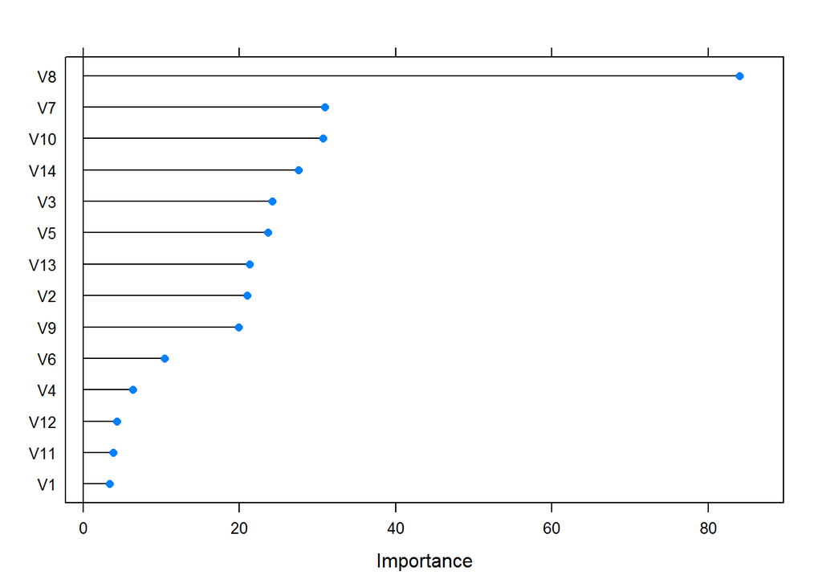

```r
plot(importance)
```

The best features are: V8, V7, V10, V14.

The worst features are: V1, V11, V12, V4.

Now, using extracted best features we can train proposed classifiers and see their performance.